# Metabolic Phenotyping Protocol

Bryan A. Hanson<sup>1</sup>

1. Professor Emeritus of Chemistry & Biochemistry, DePauw University, Greencastle IN USA.

hanson@depauw.edu

2021-09-18

This vignette was created using `ChemoSpec` version 6.0.0 and `ChemoSpecUtils` version 1.0.0.

If you aren’t familiar with `ChemoSpec`, you may wish to look at the introductory vignette before tackling this one.

# 1 Introduction

Blaise et al. (2021) have published a detailed protocol for metabolomic phenotyping. This vignette will follow their analysis closely to demonstrate how to carry it out using `ChemoSpec`. The data is composed of 139 <sup>1</sup>H HR-MAS SS-NMR spectra (Blaise et al. 2007) of the model organism *Caenorhabditis elegans*. There are two genotypes, wild type and a mutant, and worms from two life stages.

**This vignette follows the published protocol closely in order to illustrate how to implement the protocol using `ChemoSpec`. As in any chemometric analysis, there are decisions to be made about how to process the data. In this vignette we are interested in which functions to use, and how to look at the results. We are not trying to analyze the data in any systematic way, and do not consider all possible data processing choices.**

# 2 Preliminaries

**If you only want to study the workflow, you can skip this first section.**

## 2.1 Import the Data

The data set is large, over 30 Mb, so we will grab it directly from the Github repo where it is stored. We will use a custom function to grab the data (you can see the function in the source for this document if interested). The URLs point to the frequency scale, the raw data matrix and the variables that describe the sample classification by genotype and life stage (L2 are gravid adults, L4 are larvae).

```r
urls <- c("https://raw.githubusercontent.com/Gscorreia89/chemometrics-tutorials/master/data/ppm.csv",
    "https://raw.githubusercontent.com/Gscorreia89/chemometrics-tutorials/master/data/X_spectra.csv",
    "https://raw.githubusercontent.com/Gscorreia89/chemometrics-tutorials/master/data/worm_yvars.csv")
raw <- get_csvs_from_github(urls, sep = ",")  # a list of data sets
names(raw)
```

```
## [1] "ppm.csv"        "X_spectra.csv"  "worm_yvars.csv"
```

## 2.2 Construct the Spectra Object

As provided in the Github repo, the format of the data is not really suited to using either of the built-in import functions in `ChemoSpec`. Therefore we will construct the `Spectra` object by hand, a useful exercise in its own right. The requirements for a `Spectra` object are described in `?Spectra`.

### 2.2.1 Process the Raw Data

First, we’ll take the results in `raw` and convert them to the proper form. Each element of `raw` is a data frame.

```r
# frequencies are in the 1st list element
freq <- unlist(raw[[1]], use.names = FALSE)

# intensities are in the 2nd list element
data <- as.matrix(raw[[2]])
dimnames(data) <- NULL  # remove the default data frame col names
ns <- nrow(data)

# get genotype & lifestage, recode into something more readible
yvars <- raw[[3]]
names(yvars) <- c("genotype", "stage")
yvars$genotype <- ifelse(yvars$genotype == 1L, "WT", "Mut")
yvars$stage <- ifelse(yvars$stage == 1L, "L2", "L4")
table(yvars)  # quick look at how many in each group
```

```
##         stage
## genotype L2 L4
##      Mut 32 33
##      WT  34 40
```

### 2.2.2 Assemble the Spectra Object

Next we’ll construct some useful sample names, create the groups vector, assign the colors and symbols, and finally put it all together into a `Spectra` object.

```r
# build up sample names to include the group membership
sample_names <- as.character(1:ns)
sample_names <- paste(sample_names, yvars$genotype, sep = "_")
sample_names <- paste(sample_names, yvars$stage, sep = "_")
head(sample_names)
```

```
## [1] "1_WT_L4"  "2_Mut_L4" "3_Mut_L4" "4_WT_L4"  "5_Mut_L4" "6_WT_L4"
```

```r
# use the sample names to create the groups vector
grp <- gsub("[0-9]+_", "", sample_names)  # remove 1_ etc, leaving WT_L2 etc
groups <- as.factor(grp)
levels(groups)
```

```
## [1] "Mut_L2" "Mut_L4" "WT_L2"  "WT_L4"
```

```r
# set up the colors based on group membership
data(Col12)  # see ?colorSymbol for a swatch
colors <- grp
colors <- ifelse(colors == "WT_L2", Col12[1], colors)
colors <- ifelse(colors == "WT_L4", Col12[2], colors)
colors <- ifelse(colors == "Mut_L2", Col12[3], colors)
colors <- ifelse(colors == "Mut_L4", Col12[4], colors)

# set up the symbols based on group membership
sym <- grp  # see ?points for the symbol codes
sym <- ifelse(sym == "WT_L2", 1, sym)
sym <- ifelse(sym == "WT_L4", 16, sym)
sym <- ifelse(sym == "Mut_L2", 0, sym)
sym <- ifelse(sym == "Mut_L4", 15, sym)
sym <- as.integer(sym)

# set up the alt symbols based on group membership
alt.sym <- grp
alt.sym <- ifelse(alt.sym == "WT_L2", "w2", alt.sym)
alt.sym <- ifelse(alt.sym == "WT_L4", "w4", alt.sym)
alt.sym <- ifelse(alt.sym == "Mut_L2", "m2", alt.sym)
alt.sym <- ifelse(alt.sym == "Mut_L4", "m4", alt.sym)

# put it all together; see ?Spectra for requirments
Worms <- list()
Worms$freq <- freq
Worms$data <- data
Worms$names <- sample_names
Worms$groups <- groups
Worms$colors <- colors
Worms$sym <- sym
Worms$alt.sym <- alt.sym
Worms$unit <- c("ppm", "intensity")
Worms$desc <- "C. elegans metabolic phenotyping study (Blaise 2007)"
class(Worms) <- "Spectra"
chkSpectra(Worms)  # verify we have everything correct
sumSpectra(Worms)
```

[output not shown]

Let’s look at one sample from each group to make sure everything looks OK (Figure 2.1). At least these four spectra look good.

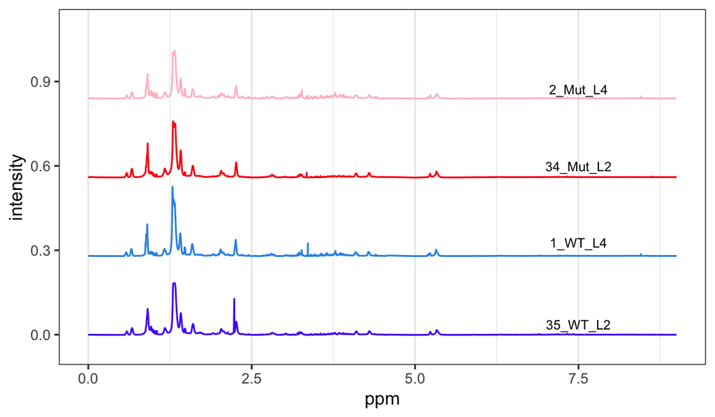

Figure 2.1: Sample spectra from each group.

```r
p <- plotSpectra(Worms, which = c(35, 1, 34, 2), lab.pos = 7.5, offset = 0.008, amplify = 35,
    yrange = c(-0.05, 1.1))
p
```

# 3 Data Analysis

We will follow the steps described in the protocol closely.

## 3.1 Normalization & Scaling

Use PQN normalization; scaling in `ChemoSpec` is applied at the PCA stage (next).

```r
Worms <- normSpectra(Worms)  # PQN is the default
```

## 3.2 PCA

```r
c_pca <- c_pcaSpectra(Worms)
```

### 3.2.1 Components to Retain

A key question at this stage is how many components are needed to describe the data set. Keep in mind that this depends on the choice of scaling. Figures 3.1 and 3.2 are two different types of scree plots, which give the residual variance. This is the R<sup>2</sup><sub>x</sub> value in the protocol (see protocol figure 7a). Another approach to answering this question is to do a cross-validated PCA. The results are shown in Figure 3.3. These are the Q<sup>2</sup><sub>x</sub> values in protocol figure 7a. All of these ways of looking at the variance explained suggest that retaining three PCs is adequate.

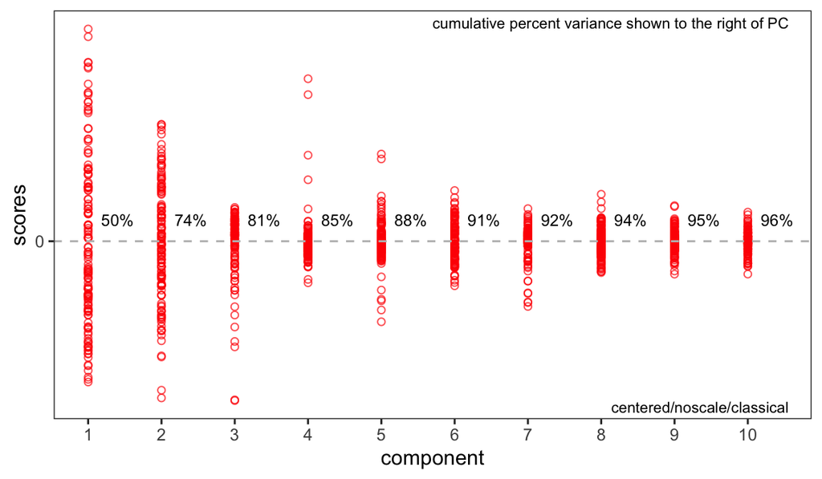

Figure 3.1: Scree plot (recommended style).

```r
plotScree(c_pca)
```

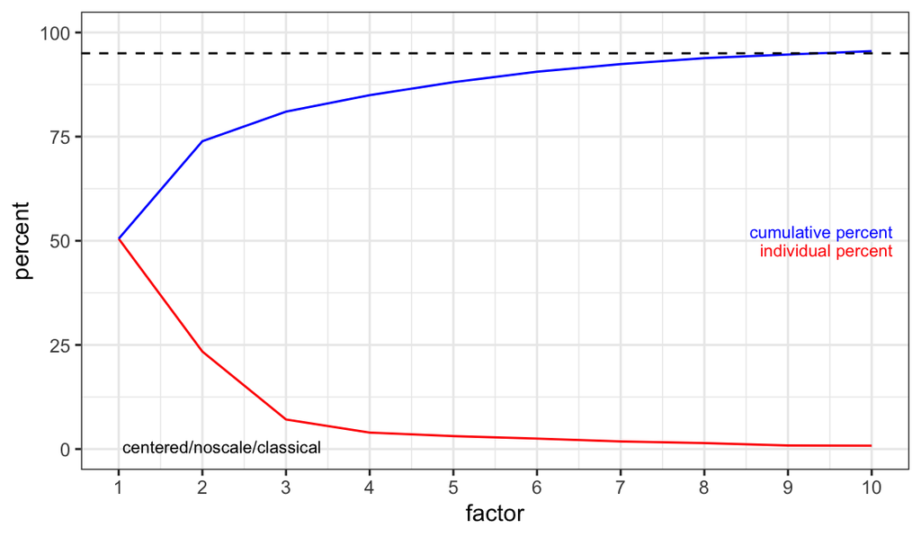

Figure 3.2: Scree plot (traditional style).

```r
plotScree(c_pca, style = "trad")
```

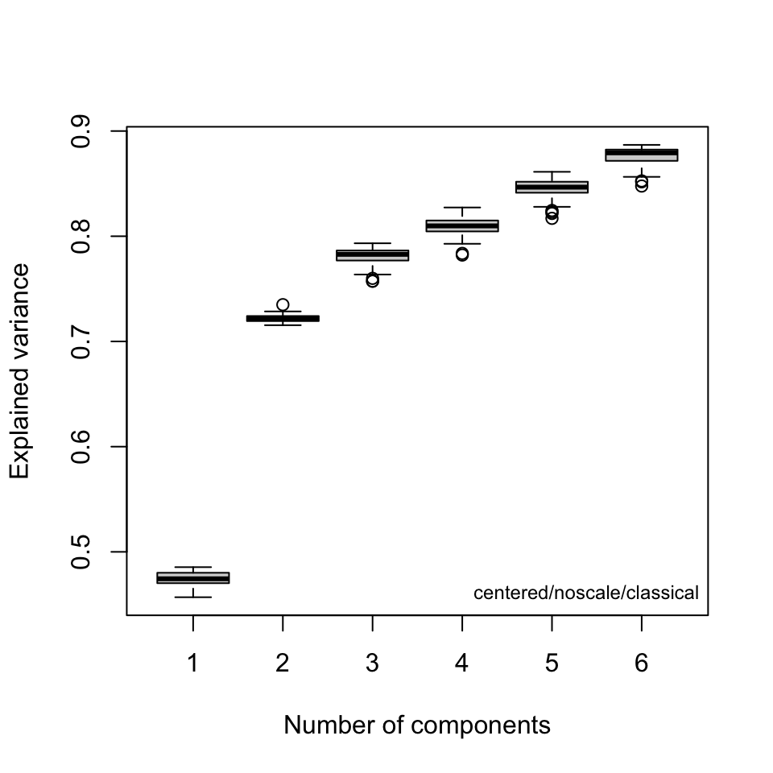

Figure 3.3: Cross-Validated PCA.

```r
cv_pcaSpectra(Worms, pcs = 6)
```

### 3.2.2 Score Plots

Next, examine the score plots (Figures 3.4, 3.5). In these plots, each data point is colored by its group membership (keep in mind this has nothing to do with the PCA calculation). In addition, robust confidence ellipses are shown for each group. Inspection of these ellipses is one way to identify potential outliers. Note that the protocol recommends plotting Hotelling’s *T*<sup>2</sup> ellipse for the entire data set; this is not implemented in `ChemoSpec`.

Inspection of these plots shows that the age of the worms (L2 vs L4) has more of an effect than than the genotype (WT vs Mut). In Figure 3.4 we don’t really see any serious outlier candiates. However, in Figure 3.5 we do see some candiates, especially for the L2 group along PC3 (two samples in particular; in the protocol they remove five samples).

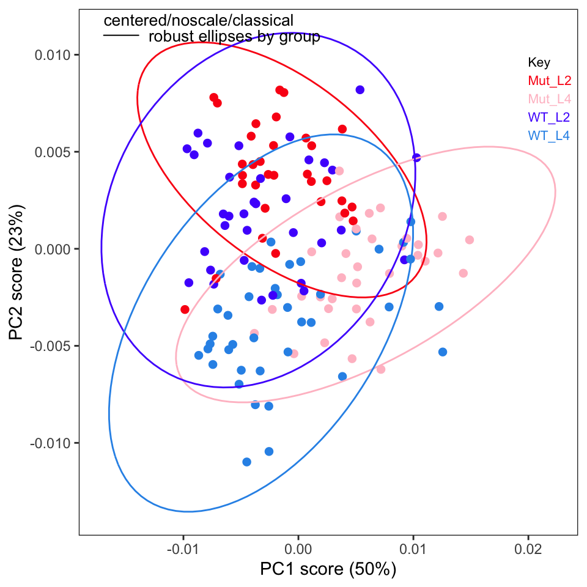

Figure 3.4: Score plot for PCs 1 & 2.

```r
p <- plotScores(Worms, c_pca, pcs = 1:2, ellipse = "rob")
p
```

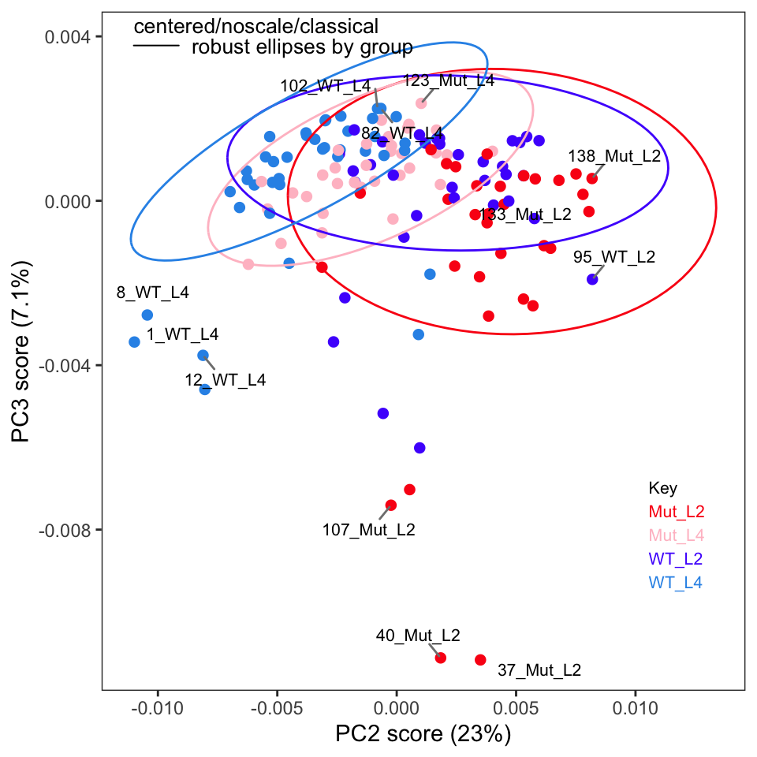

Figure 3.5: Score plot for PCS 2 & 3.

```r
p <- plotScores(Worms, c_pca, pcs = 2:3, ellipse = "rob", leg.loc = list(x = 0.85, y = 0.3),
    tol = 0.02)
p
```

### 3.2.3 Outliers

Another way to identify outliers is to use the approach described in Varmuza and Filzmoser (2009) section 3.7.3. Figures 3.6 and 3.7 give the plots. Please see Filzmoser for the details, but any samples that are above the plotted threshold line are candidate outliers, and any samples above the threshold in *both* plots should be looked at very carefully. Though we are not doing it here, Filzmoser recommends using these plots with robust PCA.

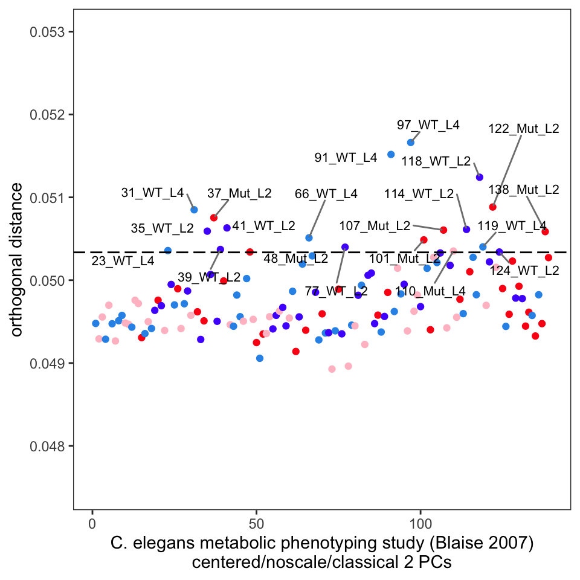

```r
p <- pcaDiag(Worms, c_pca, plot = "OD")
p <- p + coord_cartesian(ylim = c(0.0475, 0.053))
p
```

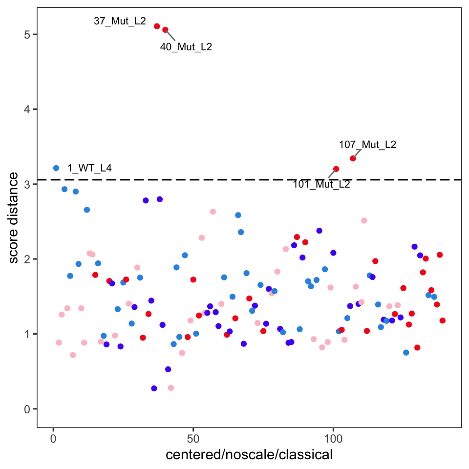

```r
p <- pcaDiag(Worms, c_pca, plot = "SD")
p
```

Analysis of these plots suggest that samples 1, 37, 40, 101 and 107 are likely outliers. They can be removed as follows.[^1]

```r
Worms <- removeSample(Worms, rem.sam = c("1_", "37_", "40_", "101_", "107_"))
```

At this point one should probably repeat the PCA, score plots and diagnostic plots to get a good look at how removing these samples affected things, but to save space those tasks are left to the reader.

One thing the protocol does not explicitly discuss is an inspection of the loadings. This is useful in order to see if any particular frequencies are driving the separation of the samples in the score plot. For the sake of completeness, we’ll go ahead and plot the loadings. See Figure 3.8. From this plot it is clear that the peaks above $\delta$ 5.0 are not contributing much to differentiating the samples. One could consider removing these peaks from the analysis, but we’ll leave them for now.

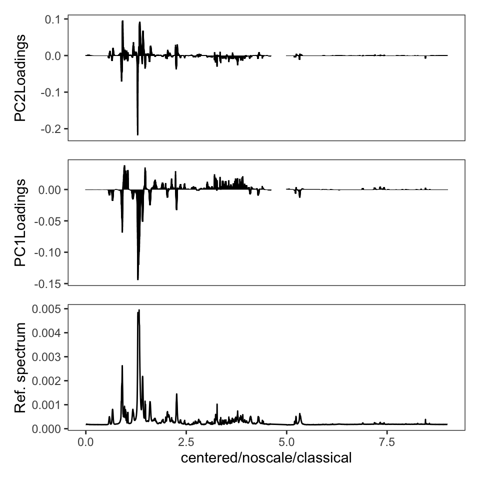

Figure 3.8: Loadings for PC1 and PC2.

```r
p <- plotLoadings(Worms, c_pca, loads = 1:2)
p
```

## 3.3 Supervised Analysis with PLS-DA

`ChemoSpec` carries out exploratory data analysis, which is an unsupervised process. The next step in the protocol is PLS-DA (partial least squares - discriminant analysis). I have written PLS [here](https://chemospec.org/2021/02/08/p17/) if you would like more background.

# References

Blaise, Benjamin J., Gonçalo D. S. Correia, Gordon A. Haggart, Izabella Surowiec, Caroline Sands, Matthew R. Lewis, Jake T. M. Pearce, et al. 2021. “Statistical Analysis in Metabolic Phenotyping.” *Nature Protocols* 16 (9): 4299–4326. https://doi.org/10.1038/s41596-021-00579-1.

Blaise, Benjamin J., Jean Giacomotto, Bénédicte Elena, Marc-Emmanuel Dumas, Pierre Toulhoat, Laurent Ségalat, and Lyndon Emsley. 2007. “Metabotyping of Caenorhabditis Elegans Reveals Latent Phenotypes.” *Proceedings of the National Academy of Sciences* 104 (50): 19808–12. https://doi.org/10.1073/pnas.0707393104.

Varmuza, K., and P. Filzmoser. 2009. *Introduction to Multivariate Statistical Analysis in Chemometrics*. CRC Press.

[^1]: Clearly removing candidate outliers is an area where you need to be very careful. If we were actually trying to reach an answer we could trust, I would recommend using `r_pcaSpectra`, the robust version of PCA, to help guide the choices.